# forcats 教程

主要参考资料： 1. https://forcats.tidyverse.org/articles/forcats.html 2. https://stat545.com/factors-boss.html

R中存储分类型变量的类叫做factor，但是base R中处理因子类比较繁琐。

`forcats` 是tidyverse家族的成员，提供了一整套处理因子类型数据的函数。“玩”好factor类型对于数据探索性分析具有重要意义，能够熟练的使用`forcats`处理因子类型的数据将使得数据分析事半功倍。

首先加载包

```r
library(dplyr)
```

```r
library(ggplot2)
library(forcats)
```

# 数据

研究数据及statwars。

```r
data("starwars")
starwars
```

| name | height | mass | hair_color | skin_color | eye_color | birth_year | gender | homeworld | species | films | vehicles | starships |
| --- | --- | --- | --- | --- | --- | --- | --- | --- | --- | --- | --- | --- |
| Luke Skywalker | 172 | 77.0 | blond | fair | blue | 19.0 | male | Tatooine | Human |  |  |  |
| C-3PO | 167 | 75.0 | NA | gold | yellow | 112.0 | NA | Tatooine | Droid |  |  |  |
| R2-D2 | 96 | 32.0 | NA | white, blue | red | 33.0 | NA | Naboo | Droid |  |  |  |
| Darth Vader | 202 | 136.0 | none | white | yellow | 41.9 | male | Tatooine | Human |  |  |  |
| Leia Organa | 150 | 49.0 | brown | light | brown | 19.0 | female | Alderaan | Human |  |  |  |
| Owen Lars | 178 | 120.0 | brown, grey | light | blue | 52.0 | male | Tatooine | Human |  |  |  |
| Beru Whitesun lars | 165 | 75.0 | brown | light | blue | 47.0 | female | Tatooine | Human |  |  |  |
| R5-D4 | 97 | 32.0 | NA | white, red | red | NA | NA | Tatooine | Droid |  |  |  |
| Biggs Darklighter | 183 | 84.0 | black | light | brown | 24.0 | male | Tatooine | Human |  |  |  |
| Obi-Wan Kenobi | 182 | 77.0 | auburn, white | fair | blue-gray | 57.0 | male | Stewjon | Human |  |  |  |

[output cut: 77 more lines]

假设我们关心角色的“头发颜色” (hair_color 变量)

```r
class(starwars$hair_color)
```

```
## [1] "character"
```

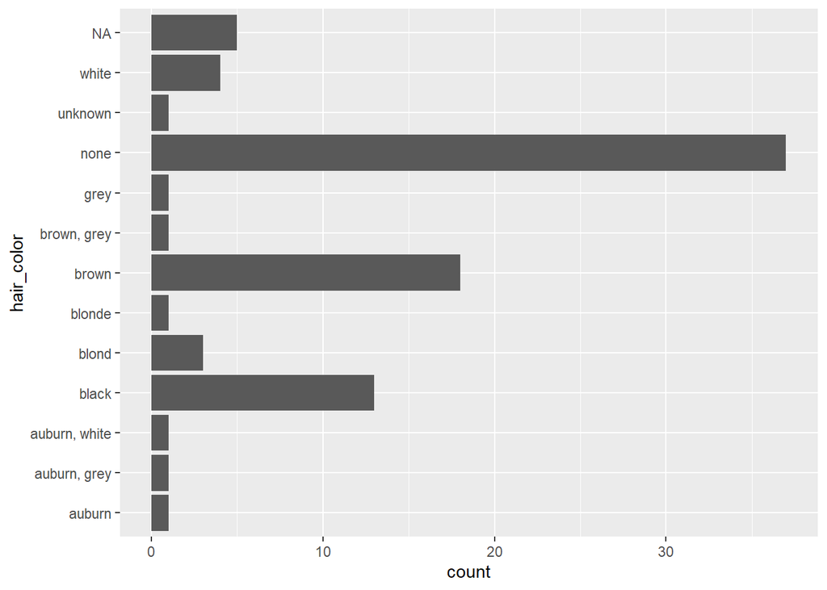

```r
ggplot(starwars, aes(x = hair_color)) +
  geom_bar() +
  coord_flip()
```

现阶段，hari_color是一个没有排序的分类变量。我们希望用它的类别出现的频数分类排序，可以使用`fct_infreq()` 函数：

# factor into frequency

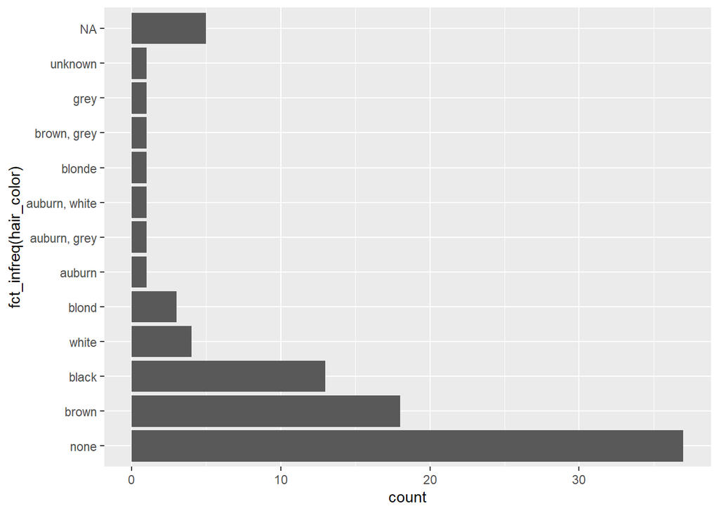

```r
ggplot(starwars, aes(x = fct_infreq(hair_color))) +
  geom_bar() +
  coord_flip()
```

`fct_infreq()` 默认将NA类放在最上面。我们应该想办法处理NA类。

```r
fct_infreq(starwars$hair_color)
```

```
##  [1] blond         <NA>          <NA>          none          brown
##  [6] brown, grey   brown         <NA>          black         auburn, white
## [11] blond         auburn, grey  brown         brown         <NA>
## [16] <NA>          brown         brown         white         grey
## [21] black         none          none          black         none
## [26] none          auburn        brown         brown         none
## [31] brown         none          blond         none          none
## [36] none          brown         black         none          black
## [41] black         none          none          none          none
## [46] none          none          none          white         none
## [51] black         none          none          none          none
## [56] none          black         brown         brown         none
## [61] black         black         brown         white         black
## [66] black         blonde        none          none          none
## [71] white         none          none          none          none
## [76] none          none          brown         brown         none
## [81] none          black         brown         brown         none
## [86] unknown       brown
## 12 Levels: none brown black white blond auburn auburn, grey ... unknown
```

# level组合

有时候某个变量的level太多，一些level只出现了很少的此处，那么我们可能想把一些罕见的level放在一起处理。使用`fct_lump()`函数：

```r
starwars %>%
  count(skin_color, sort = TRUE)
```

| skin_color | n |
| --- | --- |
| fair | 17 |
| light | 11 |
| dark | 6 |
| green | 6 |
| grey | 6 |
| pale | 5 |
| brown | 4 |
| blue | 2 |
| blue, grey | 2 |
| orange | 2 |

[output cut: 21 more lines]

```r
starwars %>%
  mutate(skin_color = fct_lump(skin_color, n = 5)) %>%
  count(skin_color, sort = TRUE)
```

| skin_color | n |
| --- | --- |
| Other | 41 |
| fair | 17 |
| light | 11 |
| dark | 6 |
| green | 6 |
| grey | 6 |

n=5表示只保留频数最高的五个level，将其他level组合放在第六个other level中。也可以使用prop代替n指定lump的最低频率（而不是频数）：

```r
starwars %>%
  mutate(skin_color = fct_lump(skin_color, prop = .1)) %>%
  count(skin_color, sort = TRUE)
```

| skin_color | n |
| --- | --- |
| Other | 59 |
| fair | 17 |
| light | 11 |

默认lump的多余level命名为other，你也可以自命名：

```r
starwars %>%
  mutate(skin_color = fct_lump(skin_color, prop = .1, other_level = "extra")) %>%
  count(skin_color, sort = TRUE)
```

| skin_color | n |
| --- | --- |
| extra | 59 |
| fair | 17 |
| light | 11 |

# 联合使用

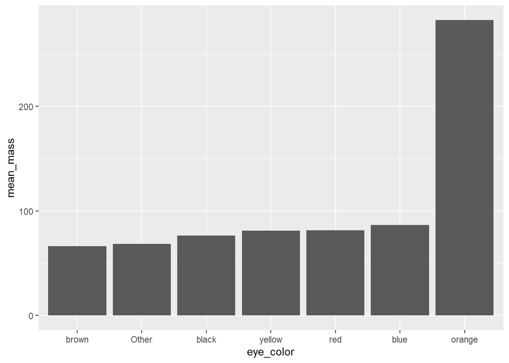

```r
avg_mass_eye_color <- starwars %>%
  mutate(eye_color = fct_lump(eye_color, n = 6)) %>%
  group_by(eye_color) %>%
  summarise(mean_mass = mean(mass, na.rm = TRUE))

avg_mass_eye_color %>%
  mutate(eye_color = fct_reorder(eye_color, mean_mass)) %>%
  ggplot(aes(x = eye_color, y = mean_mass)) +
  geom_col()
```

# fct_reorder与ggplot

reorder之后的bat plot，dot plot等更加直观。

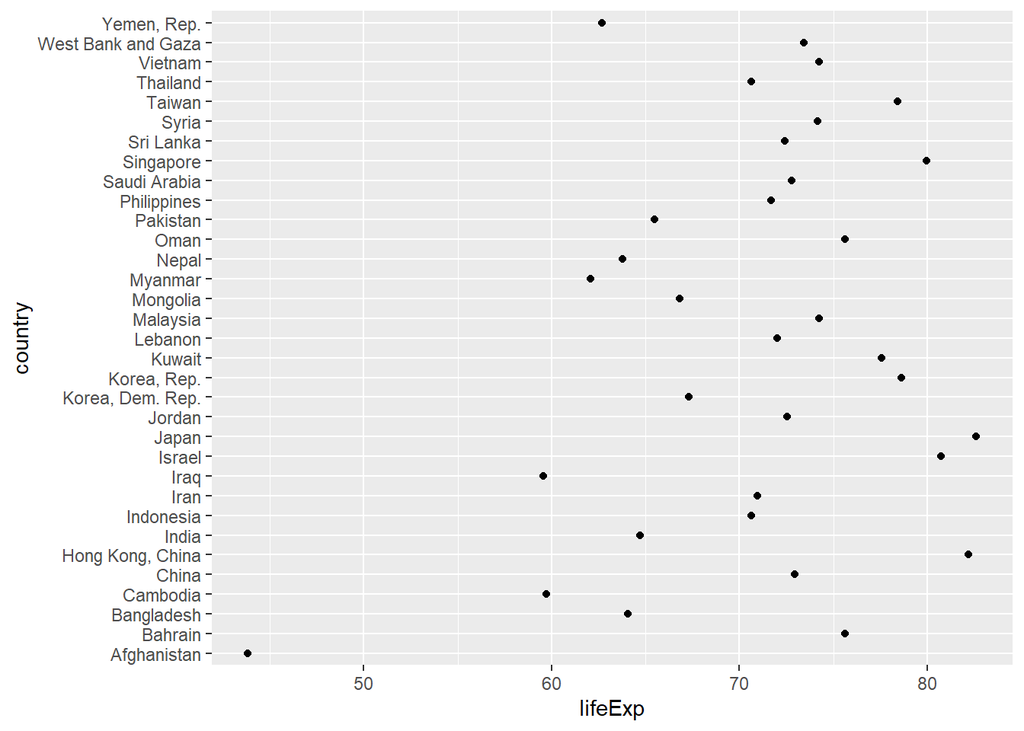

```r
library(gapminder)
gap_asia_2007 <- gapminder %>% filter(year == 2007, continent == "Asia")
ggplot(gap_asia_2007, aes(x = lifeExp, y = country)) + geom_point()
```

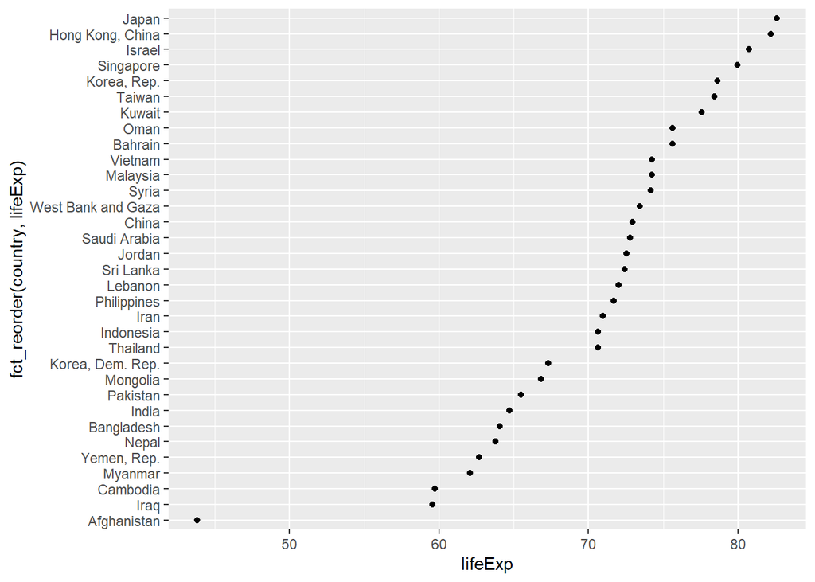

```r
ggplot(gap_asia_2007, aes(x = lifeExp, y = fct_reorder(country, lifeExp))) +
  geom_point()
```

fct_reorder2与ggplot图的color映射可以绘制更直观的图例：

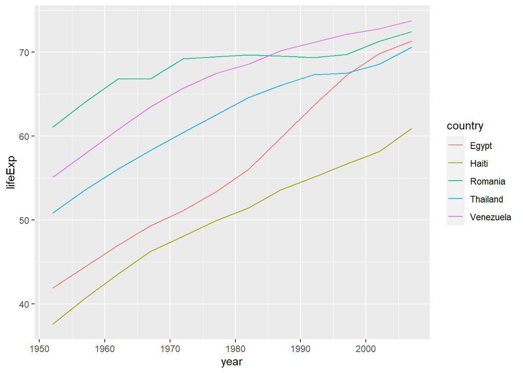

```r
h_countries <- c("Egypt", "Haiti", "Romania", "Thailand", "Venezuela")
h_gap <- gapminder %>%
  filter(country %in% h_countries) %>%
  droplevels()
ggplot(h_gap, aes(x = year, y = lifeExp, color = country)) +
  geom_line()
```

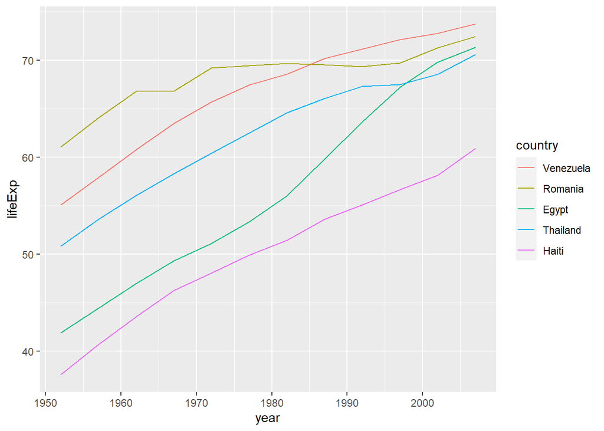

```r
ggplot(h_gap, aes(x = year, y = lifeExp,
                  color = fct_reorder2(country, year, lifeExp))) +
  geom_line() +
  labs(color = "country")
```

# relevel

```r
h_gap$country %>% levels()
```

```
## [1] "Egypt"     "Haiti"     "Romania"   "Thailand"  "Venezuela"
```

```r
h_gap$country %>% fct_relevel("Romania", "Haiti") %>% levels()
```

```
## [1] "Romania"   "Haiti"     "Egypt"     "Thailand"  "Venezuela"
```

# recode

```r
i_gap <- gapminder %>%
  filter(country %in% c("United States", "Sweden", "Australia")) %>%
  droplevels()
i_gap$country %>% levels()
```

```
## [1] "Australia"     "Sweden"        "United States"
```

```r
i_gap$country %>%
  fct_recode("USA" = "United States", "Oz" = "Australia") %>% levels()
```

```
## [1] "Oz"     "Sweden" "USA"
```

# combine factors

不可以用`c`函数组合factors，level会全部丢失。应该使用`fct_c`：

```r
df1 <- gapminder %>%
  filter(country %in% c("United States", "Mexico"), year > 2000) %>%
  droplevels()
df2 <- gapminder %>%
  filter(country %in% c("France", "Germany"), year > 2000) %>%
  droplevels()
levels(df1$country)
```

```
## [1] "Mexico"        "United States"
```

```r
c(df1$country, df2$country)
```

```
## [1] 1 1 2 2 1 1 2 2
```

```r
fct_c(df1$country, df2$country)
```

```
## [1] Mexico        Mexico        United States United States France
## [6] France        Germany       Germany
## Levels: Mexico United States France Germany
```